# DataRes NBA Fouls and Referees

Kaushik Naresh

12/18/2019

#### Getting the data frames

```r
data <- read.csv("refrefineddata.csv") # data frame of match data, used for counting number of matches...
teamref <- read.csv("Team By Referee.csv") # data frame of total fouls per team for each referee
matchref <- read.csv("Match By Referee.csv") # data frame of fouls per game for each referee (3 refs per game)
head(teamref)
```

```
##   X ref team fouls
## 1 1      ATL     0
## 2 2      BKN     0
## 3 3      BOS    22
## 4 4      CHA    20
## 5 5      CHI     0
## 6 6      CLE     0
```

```r
head(matchref)
```

```
##   X.1  X     gmDate gmTime seasTyp teamAbbr opptAbbr teamLoc teamPF opptPF
## 1   1  2 2012-10-30  19:00 Regular      CLE      WAS    Home     21     19
## 2   2  4 2012-10-30  20:00 Regular      MIA      BOS    Home     20     23
## 3   3  6 2012-10-30  22:30 Regular      LAL      DAL    Home     21     25
## 4   4  8 2012-10-31  19:00 Regular      PHI      DEN    Home     14     22
## 5   5 10 2012-10-31  19:00 Regular      TOR      IND    Home     18     16
## 6   6 12 2012-10-31  19:30 Regular      DET      HOU    Home     15     24
##                 ref
## 1     Tony Brothers
## 2   Monty McCutchen
## 3      Scott Foster
## 4 Bennett Salvatore
## 5      Bill Spooner
## 6 Courtney Kirkland
```

#### This block creates a matrix of fouls against each team by each referee, essentially contains the same data as the data frame teamref

```r
refnames <- unique(matchref$ref)
teams <- unique(matchref$teamAbbr)
ans_mat <- matrix(nrow = length(refnames), ncol = length(teams))
refnames <- sort(refnames)
teams <- sort(teams)
colnames(ans_mat) <- teams
rownames(ans_mat) <- refnames
for ( i in refnames){
  for (j in teams){
    ans_mat[i,j] <- sum(matchref$teamPF[matchref$ref == i & matchref$teamAbbr == j]) + sum(matchref$opptPF[matchref$ref == i & matchref$opptAbbr == j])
  }
}
```

#### Total fouls be referee and by team

```r
#creating a named vector with total number of fouls against each team
fouls_team <- numeric(ncol(ans_mat))
for ( i in 1:ncol(ans_mat)) fouls_team[i] <- sum(ans_mat[,i])/3 # division by three because 3 refs count each foul
names(fouls_team) <- teams

#creating a named vector with total number of fouls called by each referee
fouls_ref <- numeric(nrow(ans_mat))
for ( i in 1:nrow(ans_mat)) fouls_ref[i] <- sum(ans_mat[i,])
names(fouls_ref) <- refnames

fouls_team
```

```
##   ATL   BKN   BOS   CHA   CHI   CLE   DAL   DEN   DET    GS   HOU   IND
##  9174  9746 10298  8805  9248  9563  9718 10277  9379 10058 10162  9822
##   LAC   LAL   MEM   MIA   MIL   MIN    NO    NY   OKC   ORL   PHI   PHO
## 10243  9931 10319  9595 10189  9421  9832 10198 10399  9848 10510 10925
##   POR    SA   SAC   TOR   UTA   WAS
##  9705  8825 10244 10531  9841 10262
```

```r
fouls_ref
```

```
##                                 Aaron Smith            Ben Taylor
##                    81                  4630                 11389
##     Bennett Salvatore          Bennie Adams          Bill Kennedy
##                  6131                 14104                 15885
##          Bill Spooner         Brandon Adair        Brenda Pantoja
##                 12417                   240                   293
##         Brent Barnaky          Brett Nansel           Brian Forte
##                 14376                  4021                 15446
##       C.J. Washington     Courtney Kirkland          Curtis Blair
##                  3969                 15013                 13385
##          Dan Crawford         David Guthrie           David Jones
##                 12416                 14578                  9025
##         Dedric Taylor      Derek Richardson       Derrick Collins
##                  9109                 12399                 15710
##      Derrick Stafford          Dick Bavetta             Ed Malloy
##                 13351                  4186                 14522
##            Eddie Rush               Eli Roe            Eric Dalen
##                  1582                  8928                 11307
##            Eric Lewis        Gary Zielinski   Gediminas Petraitis
##                 16050                 15221                  6708
##      Haywoode Workman              J.T. Orr           Jacyn Goble
##                 13257                 13295                  3329
##          James Capers        James Williams      Jason Goldenberg
##                 15141                 14506                  1733
##        Jason Phillips          Joe Crawford            Joe DeRosa
##                 12528                  7536                  1363
##            John Goble     Jonathan Sterling            Josh Tiven
##                 16526                  1663                 15641
##      Justin Van Duyne       Kane Fitzgerald             Karl Lane
##                  9765                 16319                 13955
##             Ken Mauer          Kevin Cutler            Kevin Fehr
##                 14710                 13906                  2231
##           Kevin Scott        Kipp Kissinger       Lauren Holtkamp
##                 14183                    74                  8726
##             Leon Wood      Leroy Richardson           Marat Kogut
##                 13865                 14720                 13787
##            Marc Davis           Mark Ayotte          Mark Lindsay
##                 15221                 14952                 15312
##           Matt Boland            Matt Myers         Michael Smith
##                 14192                   103                 15062
##         Mike Callahan        Mitchell Ervin       Monty McCutchen
##                 14259                  6361                 13939
##          Nick Buchert         Olandis Poole            Pat Fraher
##                 14263                  4090                 14833
##       Phenizee Ransom      Randy Richardson            Ray Acosta
##                   402                   210                  1357
##           Rodney Mott         Ron Garretson         Scott Bolnick
##                 12787                 13885                   348
##          Scott Foster       Scott Twardoski            Scott Wall
##                 16485                 13274                 13836
##           Sean Corbin           Sean Wright       SirAllen Conner
##                 14263                 15322                   101
##       Steven Anderson        Tom Washington         Tony Brothers
##                  8304                 15774                 15009
##            Tony Brown            Tre Maddox            Tyler Ford
##                 14824                 13699                  7260
##         Violet Palmer Vladimir Voyard-Tadal            Zach Zarba
##                  5368                   509                 16369
```

#### Graphs of total fouls by team and total fouls by referee

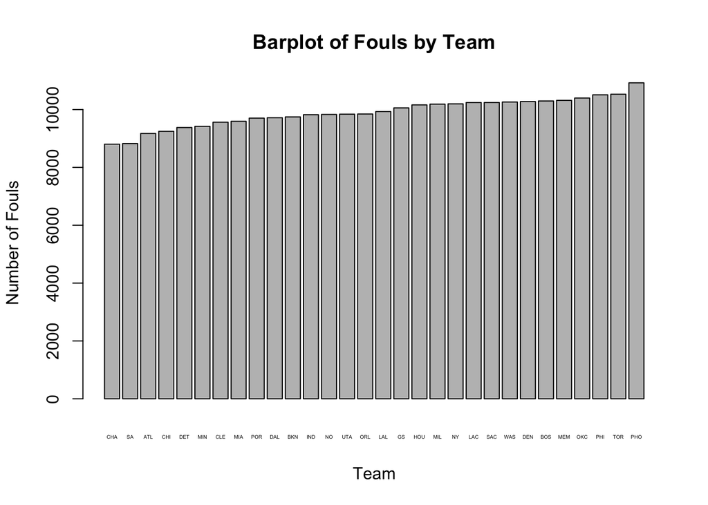

```r
barplot(sort(fouls_team), xlab = "Team", ylab = "Number of Fouls",  cex.names = 0.3, main= "Barplot of Fouls by Team")
```

As can be seen from this graph, all teams have had at least 8000 fouls called against them in the years 2012-2018, and the three teams with the most fouls called are the Phoenix Suns, Toronto Raptors, and Philadelphia 76ers while the three teams with the lowest fouls are the Atlanta Hawks, San Antonio Spurs, and Charlotte Hornets. However, a problem here is that some teams may have played more games than others (due to playoffs) and so we need to look at averages.

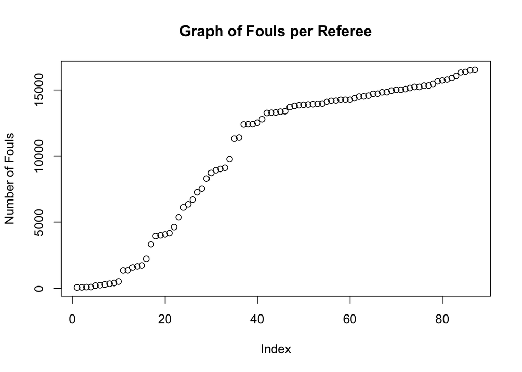

```r
plot(sort(fouls_ref), ylab = "Number of Fouls", main = "Graph of Fouls per Referee", xlab = "Index")
```

#### Calculating average fouls by team and average fouls by referee

```r
# create vector for number of matches per team & then average fouls done
matches_team <- numeric(length(fouls_team))
for (i in 1:length(matches_team)) matches_team[i] <- sum(data$teamAbbr == names(fouls_team)[i] | data$opptAbbr == names(fouls_team)[i])
avg_team <- fouls_team/matches_team

#create vector for number of matches per referee & then average fouls called
matches_ref <- numeric(length(fouls_ref))
for (i in 1:length(matches_ref)) matches_ref[i] <- sum(matchref$ref == names(fouls_ref)[i])
avg_ref <- fouls_ref/matches_ref
```

#### Graphs of average fouls by team and average fouls by referee

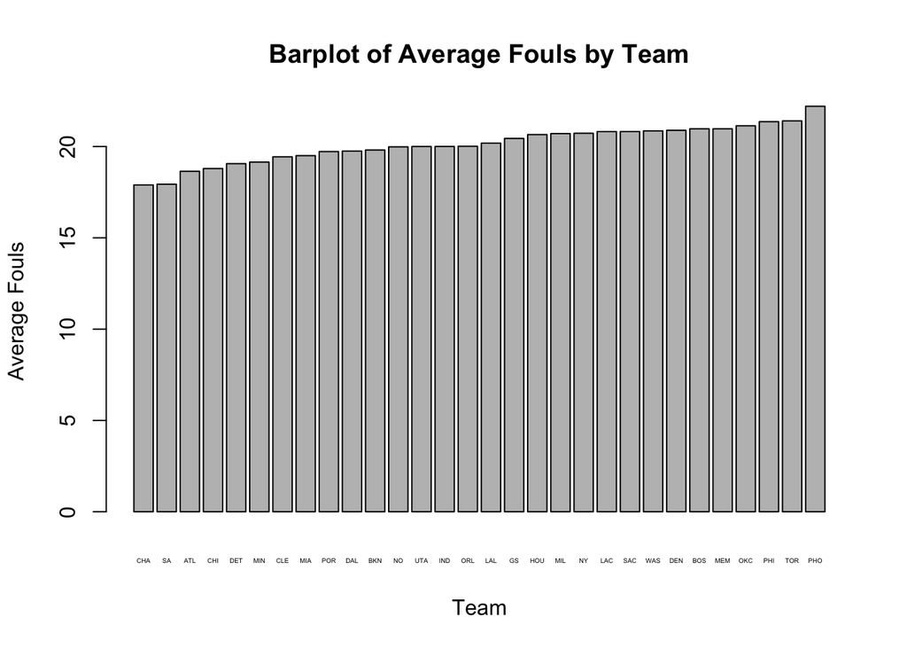

```r
barplot(sort(avg_team), xlab = "Team", ylab = "Average Fouls",  cex.names = 0.3, main= "Barplot of Average Fouls by Team")
```

As can be seen, the average number of fouls per team for all teams is definitely above 17, and much like the previous barplot, the top 3 (Phoenix Suns, Toronto Raptors, Philadelphia 76ers) and bottom 3 (Charlotte Hornets, San Antonio Spurs, Atlanta Hawks) teams are the same. However, the order of teams in the middle is slightly different in this plot. Still, there does not appear to be too much of a difference suggesting that over the 6 years, these teams have probably all played around the same number of games even after factoring playoffs.

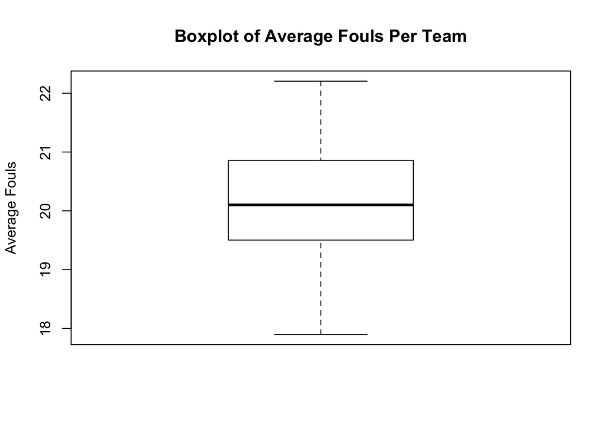

```r
boxplot(avg_team, main = "Boxplot of Average Fouls Per Team", ylab = "Average Fouls")
```

This boxlpot shows that the average number of fouls called lies between 18 and 22 for all teams with the median at around 20. There are also no outliers in this plot.

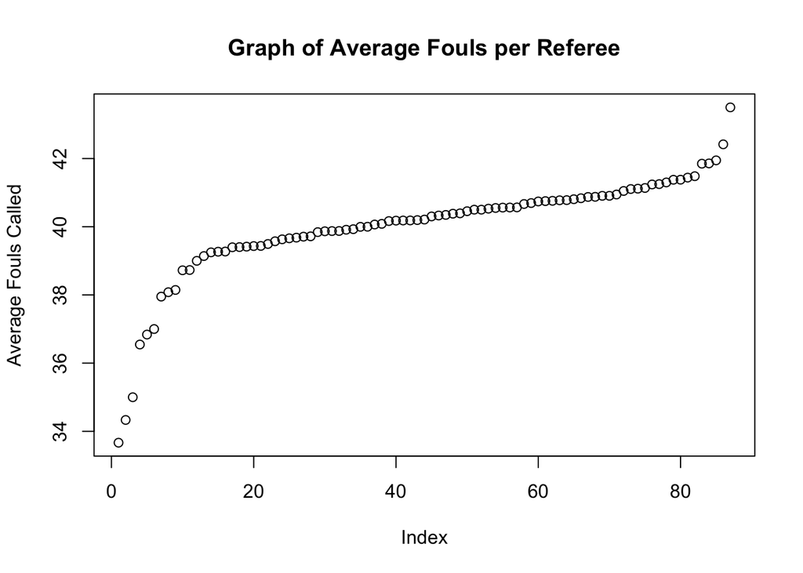

```r
plot(sort(avg_ref), ylab = "Average Fouls Called", main = "Graph of Average Fouls per Referee", xlab = "Index")
```

From this graph we can see that most referees, around 80% call between 38 and 42 fouls per game, which comes to 19-21 fouls per team per game, suggesting that there are very few referees who call an excessive amount, or a lower amount of fouls. It is difficult to label these points, so a detailed analysis of the extremes will follow.

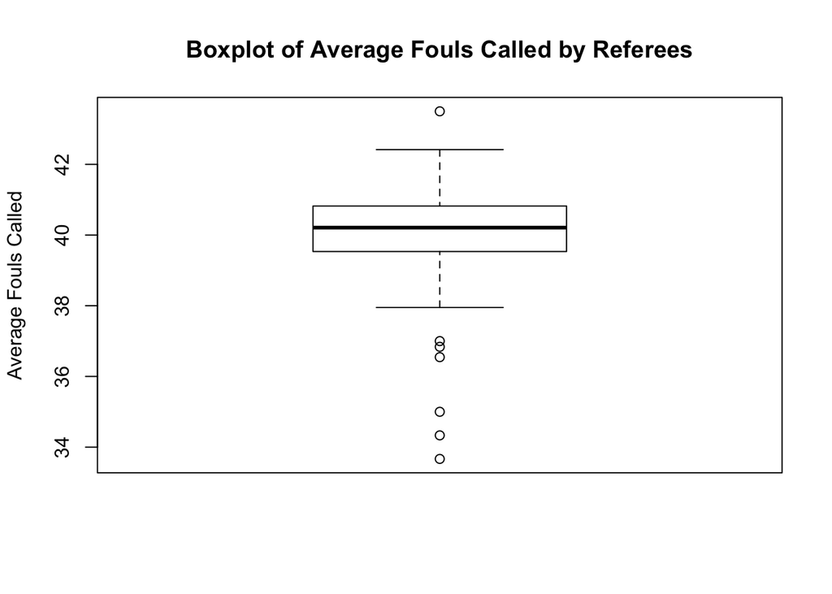

```r
boxplot(avg_ref, main = "Boxplot of Average Fouls Called by Referees", ylab = "Average Fouls Called")
```

As can be seen, this boxplot confirms the previous analysis since all the outliers lie outside of the 38-42 range and the median is at around 40.

Now moving on to the referees that call most fouls and least fouls. (sorted by average) #### Creating dataframes for the referees that call the least and most fouls

```r
ref_least <- names(sort(avg_ref)[1:3])
ref_most <- names(sort(avg_ref, decreasing = TRUE)[1:3])
df_leastref <- teamref[teamref$ref == ref_least[1] | teamref$ref == ref_least[2] | teamref$ref == ref_least[3],]
df_mostref <- teamref[teamref$ref == ref_most[1] | teamref$ref == ref_most[2] | teamref$ref == ref_most[3],]
df_mostref <- df_mostref[df_mostref$fouls != 0,]
df_leastref <- df_leastref[df_leastref$fouls != 0,]
```

#### Graphs for the top 3 most calls and lowest 3 calls

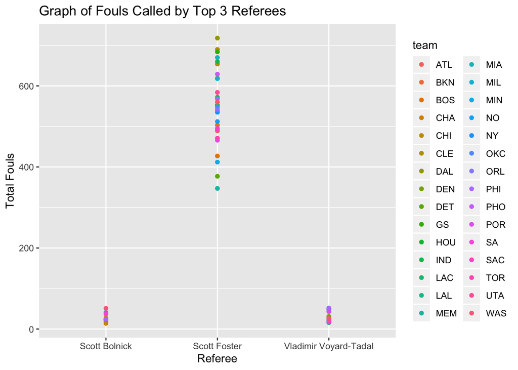

```r
ggplot(data = df_mostref, aes(x = ref, y = fouls, color = team)) + geom_point() + labs(title = "Graph of Fouls Called by Top 3 Referees", x = "Referee", y = "Total Fouls")
```

These are the top 3 referees who call the highest average number of fouls. As can be seen, Scott Bolnick and Vladamir Voyard Tadal do not seem to call too many fouls for any certain team in comparison to other teams. However, Scott Foster seems to have called a lot more fouls against Dallas, Chicago, and Houston, while he called much lesser fouls against Miami, Detroit and Minnesota.

Interestingly there are articles about Scott Foster where players have expressed a dislike towards his officiating. A quote from Paul Pierce (who played for Boston, LA Clippers, Brooklyn) is as follows: “I know that Scott is going to have a quick trigger with the technicals.” Now as can be seen on the graph he has called a large number of fouls against each team, around 500+ for most, and his average number of fouls is 42 per game, which is definitely a pretty high number.

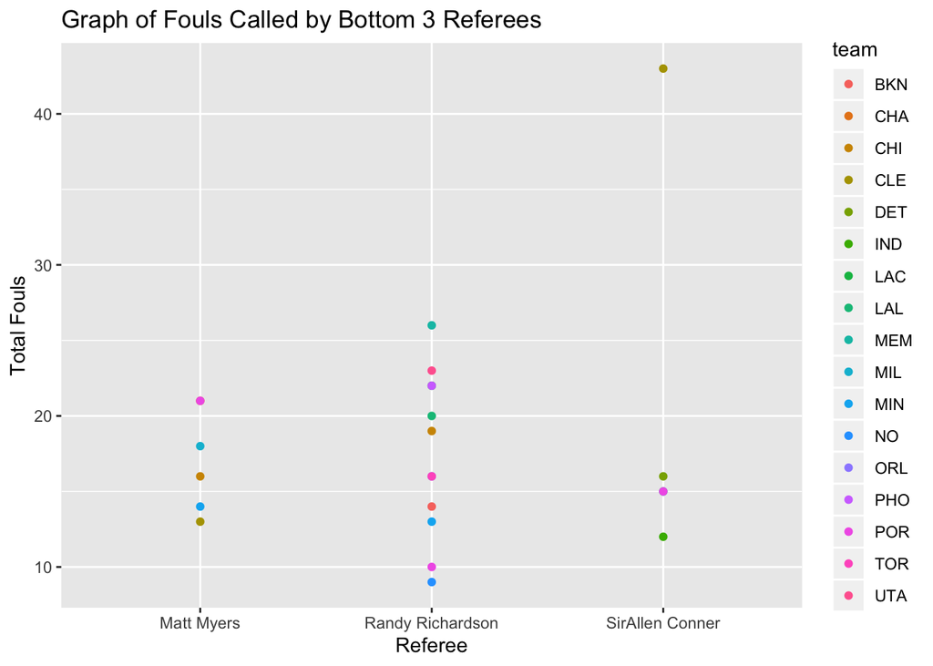

```r
ggplot(data = df_leastref, aes(x = ref, y = fouls, color = team)) + geom_point() + labs(title = "Graph of Fouls Called by Bottom 3 Referees", x = "Referee", y = "Total Fouls")
```

Matt Myers is from the Midwest and interstingly, he has called lesser fouls against multiple midwest teams (Cleveland, Minnesota, Chicago). One important fact to note is that all these referees are replacement referees and did not referee for many seasons. This could be related to why they call the lowest average number of fouls.

Now moving on to the team with the most fouls and least fouls. (sorted by average) #### creating the data frames for the team with most fouls (Phoenix) and the teams with least fouls (Charlotte)

```r
max_team <- names(sort(avg_team, decreasing = TRUE))[1]
min_team <- names(sort(avg_team))[1]

df_teammax <- teamref[teamref$team == max_team,]
df_teammin <- teamref[teamref$team == min_team,]

df_teammax <- df_teammax[df_teammax$fouls != 0,]
df_teammin <- df_teammin[df_teammin$fouls != 0,]

x <- quantile(df_teammax$fouls, probs = c(0.1, 0.9))
y <- quantile(df_teammin$fouls, probs = c(0.1, 0.9) )

df_teammax <- df_teammax[df_teammax$fouls > x[2] | df_teammax$fouls < x[1],]
df_teammin <- df_teammin[df_teammin$fouls > y[2] | df_teammin$fouls < y[1],]
```

#### graphs

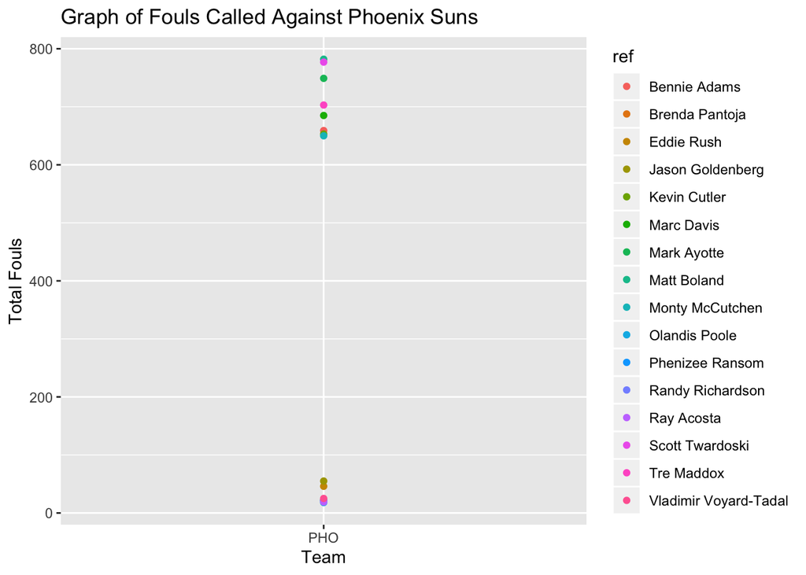

```r
ggplot(data=df_teammax, aes(x = team, y = fouls, color = ref)) + geom_point() + labs(title = "Graph of Fouls Called Against Phoenix Suns", x = "Team", y = "Total Fouls")
```

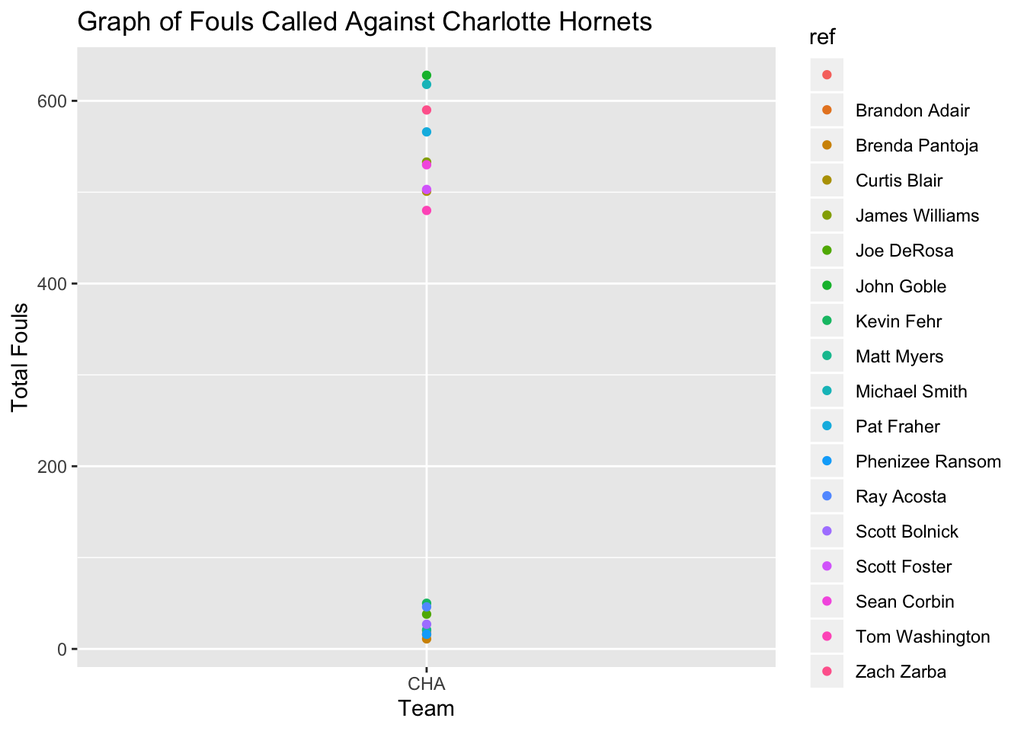

```r
ggplot(data=df_teammin, aes(x = team, y = fouls, color = ref)) + geom_point() + labs(title = "Graph of Fouls Called Against Charlotte Hornets", x = "Team", y = "Total Fouls")
```